# Data Science Portfolio

## **Price Optimisation ML Model**

### **The pipeline included three steps:**

- **Forecast of the average price of luxury hotels in the region.**  
  In the feature creation phase this variable was found to be a good predictor.
- **Find the optimal price that yields the highest probability of having a high room occupancy.**  
  A classification model using the Random Forest algorithm was used. This is a novel approach to price optimization, as Operational Research practices would normally use other methods, however more difficult to put into production.
- **Reporting**  
  Easy to read visualizations that help Revenue Managers make decisions about the pricing.

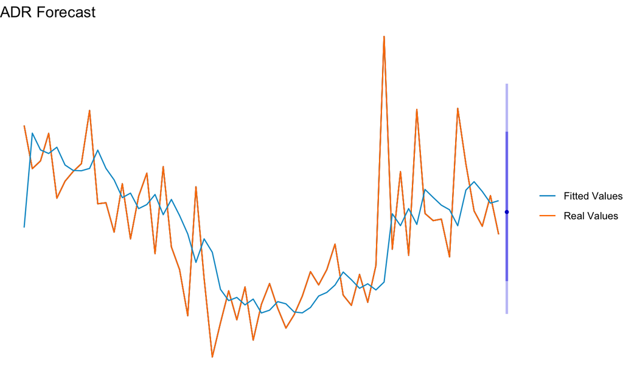

Average price of luxury hotels in the region forecasting using ARIMA (0,1,1); this value is later used as a predictor of the main model. As shown, the values predicted by the model clearly follow the real values’ trend.

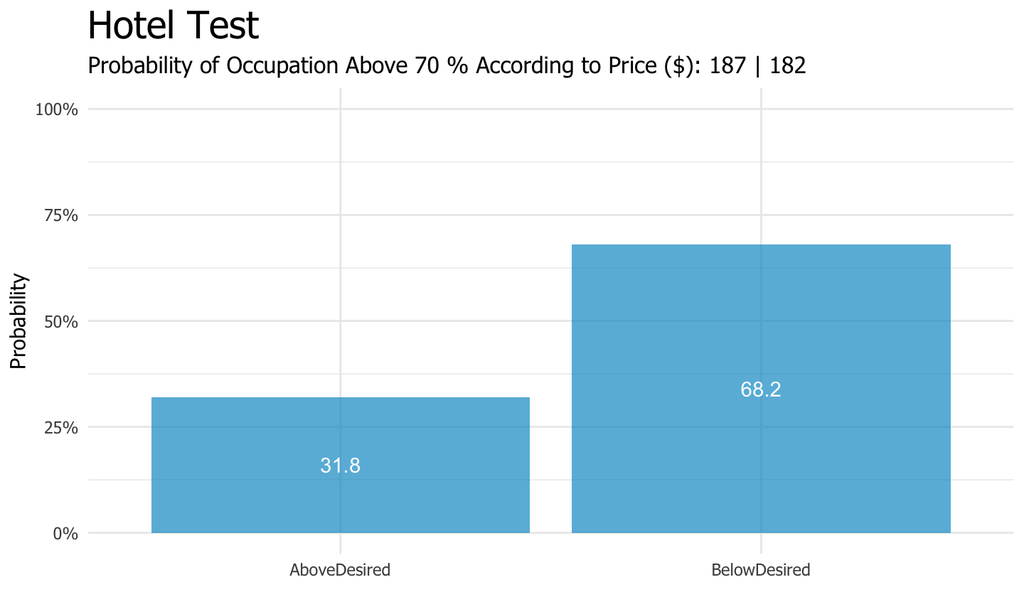

In this example, on the date of analysis there is a 68.2% probability of having an occupancy rate below the threshold defined with the customer (70%). This low occupancy is expected even with the optimal price determined by the model.

## **Lifetime Value prediction using CRM data**

### **The pipeline included two steps:**

- **Segmentation of users according to their Length, Recency, Frequency, Monetary, Periodicity of transactions**  
  The original publication of this model can be found by entering [this link](https://www.emeraldinsight.com/doi/abs/10.1108/MIP-11-2016-0210).
- **Fitting a model that predicts future user engagement.**  
  Fitting a model per cluster was found to improve the balance between Sensitivity and Specificity, as well as capture the variable importance among users with similar transactional patterns. This framework was used as a prescriptive analysis to inform the strategic goals of a non-profit organisation.

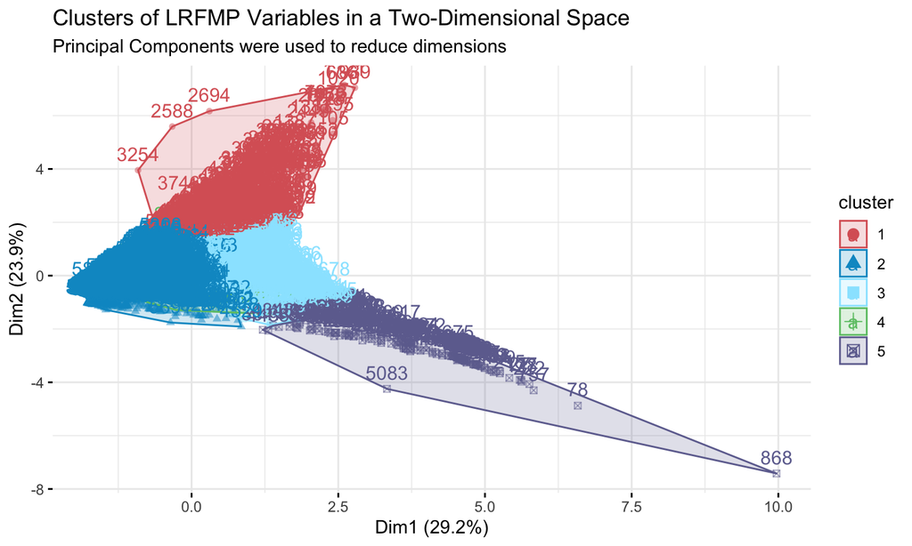

Five segments were identified, each with their own transactional patterns. A characterization was performed after further analysis of the clusters.

| Cluster | ROC AUC | Sensitivity | Specificity |
| --- | --- | --- | --- |
| 1 | 0.72 | 0.85 | 0.47 |
| 2 | 0.77 | 0 | 1 |
| 2 (SMOTE) | 0.79 | 0.42 | 0.91 |
| 3 | 0.81 | 0.47 | 0.89 |
| 4 | 0.78 | 0.57 | 0.8 |
| 5 | N/A | N/A | N/A |

A classification model was performed, gathering concepts from Churn Prediction and Lifetime Value models, adapting them to the problem to solve.

## **Interactive Web-Dashboards using reactive programming**

- **Operational Dashboards.**  
  As operational tools or managerial information systems, dashboards can inform the business about KPI’s performance. To see an example access [this link](https://ftoresh.shinyapps.io/portfolio_dash/)
- **Rapid prototyping.**  
  Prototyping dashboards to get approval from stakeholders. Once approved, they can be replicated into a more complex information system.

## **Merge data from different sources to form a unique reality**

Clic [here](https://www.youtube.com/watch?v=22a7iOIU6sw&feature=youtu.be) to see a real example of data gathered from two different sources, then joined to form a unique reality on a geospacial dashboard.

The code of this portfolio can be seen on my Github account following [this repository](https://github.com/ftoresh/Projects-Portfolio/blob/master/Portfolio%20presentation%20script.Rmd).